# MPDW - Pertemuan 3

# Library

```r
library(readxl)
library(dplyr)
library(janitor)
library(ggplot2)
library(zoo)
library(dynlm)
library(lmtest)
library(tseries)
library(sandwich)
library(forecast)
library(dLagM)
library(dynlm)
library(MLmetrics)
library(car)
library(rio)
```

# **Data**

## Pemilihan Peubah X dan Peubah Y

```r
data_full <- rio::import("C:/Users/MUTIARA ARDIANA/OneDrive/Desktop/SEMESTER 5/[3] MPDW/3 MPDW/AQI New Delhi.xlsx", sheet = 1)
str(data_full)
```

```
## 'data.frame':    72 obs. of  12 variables:
##  $ ...1           : num  0 1 2 3 4 5 6 7 8 9 ...
##  $ AQI            : num  30.2 28.2 26.6 25 26 26 26 24 23 24 ...
##  $ CO             : num  199 198 199 202 205 ...
##  $ datetime       : chr  "2022-10-21:18" "2022-10-21:19" "2022-10-21:20" "2022-10-21:21" ...
##  $ no2            : num  0.0469 0.0465 0.0469 0.0482 0.0489 ...
##  $ o3             : num  55.8 54.9 54.6 55.1 55.8 ...
##  $ pm10           : num  10.5 10.7 11.2 11.1 10.4 ...
##  $ pm25           : num  5.64 4.62 3.52 2.23 1.98 ...
##  $ so2            : num  0.387 0.41 0.402 0.376 0.339 ...
##  $ timestamp_local: POSIXct, format: "2022-10-21 23:00:00" "2022-10-22 00:00:00" ...
##  $ timestamp_utc  : POSIXct, format: "2022-10-21 18:00:00" "2022-10-21 19:00:00" ...
##  $ ts             : num  1.67e+09 1.67e+09 1.67e+09 1.67e+09 1.67e+09 ...
```

```r
data_full
```

```
##    ...1  AQI       CO      datetime        no2       o3      pm10     pm25
## 1     0 30.2 198.6027 2022-10-21:18 0.04685717 55.78995 10.486722 5.637410
## 2     1 28.2 197.6013 2022-10-21:19 0.04645554 54.93164 10.719325 4.618169
## 3     2 26.6 198.6027 2022-10-21:20 0.04685717 54.64554 11.155578 3.520902
## 4     3 25.0 201.9405 2022-10-21:21 0.04819594 55.07469 11.116206 2.225919
## 5     4 26.0 205.2784 2022-10-21:22 0.04886533 55.78995 10.405250 1.979471
## 6     5 26.0 208.6163 2022-10-21:23 0.05020411 56.50520  9.402518 1.792677
## 7     6 26.0 208.6163 2022-10-22:00 0.05020411 55.78995  8.482822 1.752237
## 8     7 24.0 205.2784 2022-10-22:01 0.05020411 52.92892  7.586667 1.858459
## 9     8 23.0 200.2716 2022-10-22:02 0.04685717 50.06790  7.636587 2.208076
## 10    9 24.0 196.9338 2022-10-22:03 0.04417961 51.49841  8.487648 2.476681
## 11   10 25.0 198.6027 2022-10-22:04 0.04284084 53.64418  9.357371 2.585729
## 12   11 26.0 200.2716 2022-10-22:05 0.04049798 55.78995 10.338728 2.390081
## 13   12 27.0 203.6095 2022-10-22:06 0.04016329 59.36623 10.523314 2.086022
## 14   13 29.0 205.2784 2022-10-22:07 0.03882451 62.22725 10.635970 1.937047
```

[output cut: 131 more lines]

Dalam penelitian ini, **PM2.5** akan dipilih sebagai **peubah penjelas (xt)** untuk memodelkan **AQI (yt)**. Keputusan ini didasarkan pada temuan studi *Implementation of Random Forest Algorithm for Air Quality Classification: A Case Study of DKI Jakarta’s Air Quality Index* (2025),yang menunjukkan bahwa komponen partikulat mendominasi pembentukan AQI di DKI Jakarta, dengan **PM2.5** menyumbang pengaruh terbesar (**46,62%**), disusul **PM10** (**32,08%**). Dengan pertimbangan ilmiah dan bukti empiris tersebut, kami menetapkan pemetaan variabel sebagai berikut:

**`t`** = indeks jam pengamatan

`Yt` = nilai AQI pada jam ke-t

`Yt-1` = lag 1 jam AQI

`Xt` = kadar PM2.5 pada jam yang sama

**Link Jurnal:** [Implementation of Random Forest Algorithm for Air Quality Classification: A Case Study of DKI Jakarta’s Air Quality Index (2025)](https://www.ijisrt.com/assets/upload/files/IJISRT25MAR1548.pdf)

## Data Pakai

```r
data <- rio::import("C:/Users/MUTIARA ARDIANA/OneDrive/Desktop/SEMESTER 5/[3] MPDW/3 MPDW/AQI New Delhi.xlsx", sheet = 2)
str(data)
```

```
## 'data.frame':    72 obs. of  4 variables:
##  $ t   : num  1 2 3 4 5 6 7 8 9 10 ...
##  $ Yt  : num  30.2 28.2 26.6 25 26 26 26 24 23 24 ...
##  $ Yt-1: num  NA 30.2 28.2 26.6 25 26 26 26 24 23 ...
##  $ Xt  : num  5.64 4.62 3.52 2.23 1.98 ...
```

```r
data
```

```
##     t   Yt Yt-1       Xt
## 1   1 30.2   NA 5.637410
## 2   2 28.2 30.2 4.618169
## 3   3 26.6 28.2 3.520902
## 4   4 25.0 26.6 2.225919
## 5   5 26.0 25.0 1.979471
## 6   6 26.0 26.0 1.792677
## 7   7 26.0 26.0 1.752237
## 8   8 24.0 26.0 1.858459
## 9   9 23.0 24.0 2.208076
## 10 10 24.0 23.0 2.476681
## 11 11 25.0 24.0 2.585729
## 12 12 26.0 25.0 2.390081
## 13 13 27.0 26.0 2.086022
## 14 14 29.0 27.0 1.937047
```

[output cut: 58 more lines]

```r
names(data)
```

```
## [1] "t"    "Yt"   "Yt-1" "Xt"
```

```r
data <- data |>
  mutate(
    "Yt" = as.numeric(Yt),
    "Yt-1" = as.numeric(Yt-1),
    "Xt" = as.numeric(Xt)
  ) |>
  filter(!is.na(Yt) & !is.na(Xt))
nrow(data)
```

```
## [1] 72
```

# EDA

```r
summary(data[, c("Yt", "Xt")])
```

```
##        Yt              Xt
##  Min.   :19.00   Min.   :1.633
##  1st Qu.:25.00   1st Qu.:1.829
##  Median :27.00   Median :2.202
##  Mean   :26.18   Mean   :2.295
##  3rd Qu.:28.00   3rd Qu.:2.522
##  Max.   :32.00   Max.   :5.637
```

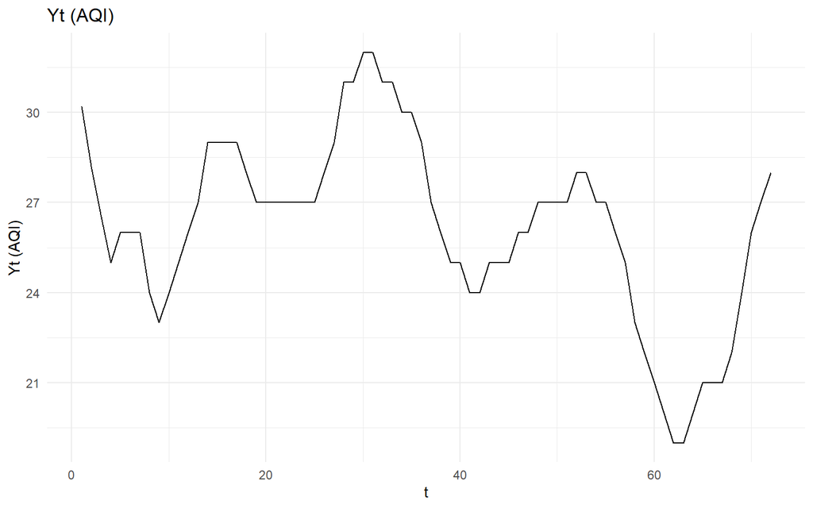

```r
autoplot_ts <- function(y, ttl) {
  ggplot(data.frame(t = seq_along(y), y = y),
         aes(t, y)) + geom_line() +
    labs(x = "t", y = ttl, title = ttl) + theme_minimal()
}
autoplot_ts(data$Yt, "Yt (AQI)")
```

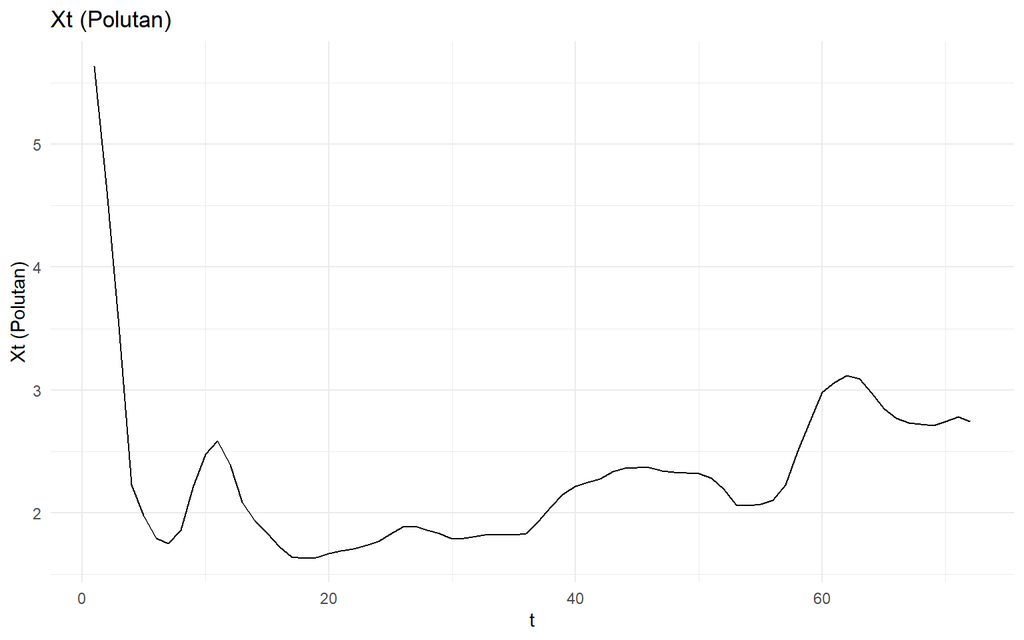

```r
autoplot_ts(data$Xt, "Xt (Polutan)")
```

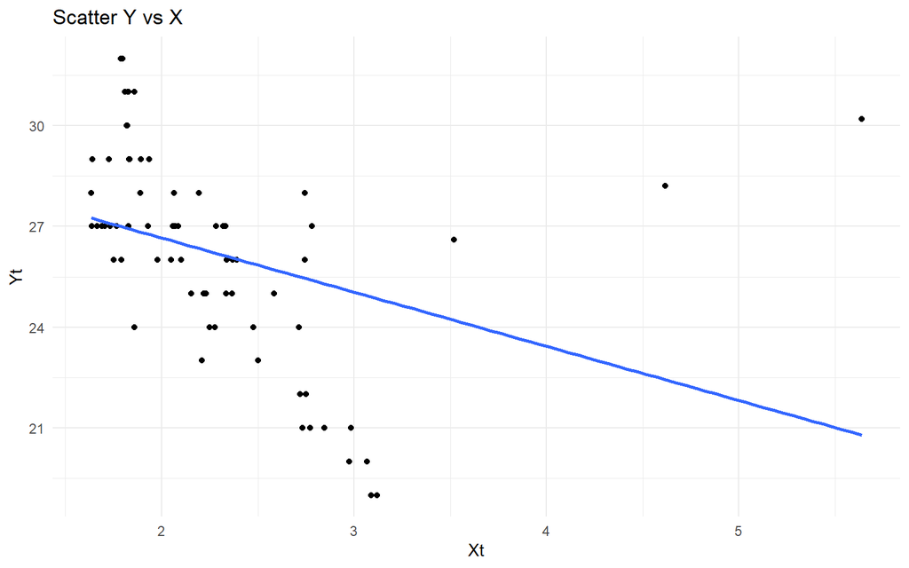

```r
ggplot(data, aes(x = Xt, y = Yt)) +
  geom_point() + geom_smooth(method = "lm", se = FALSE) +
  labs(title="Scatter Y vs X", x = "Xt", y = "Yt") + theme_minimal()
```

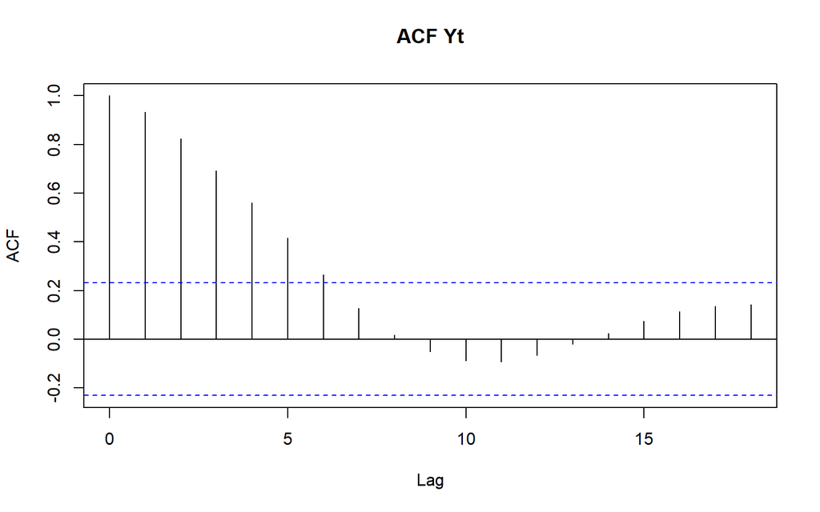

```r
acf(data$Yt, main="ACF Yt")
```

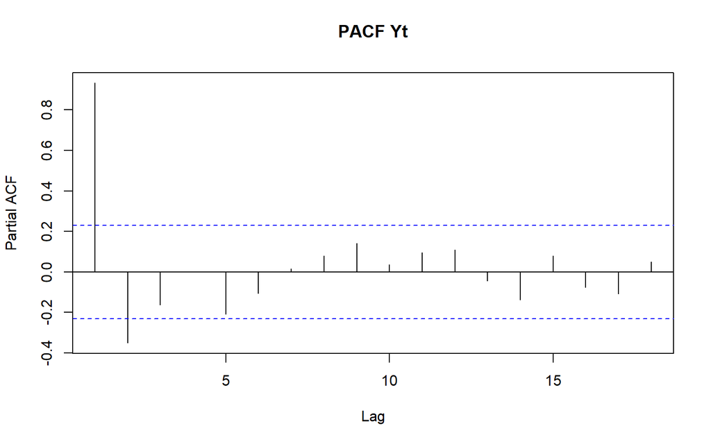

```r
pacf(data$Yt, main="PACF Yt")
```

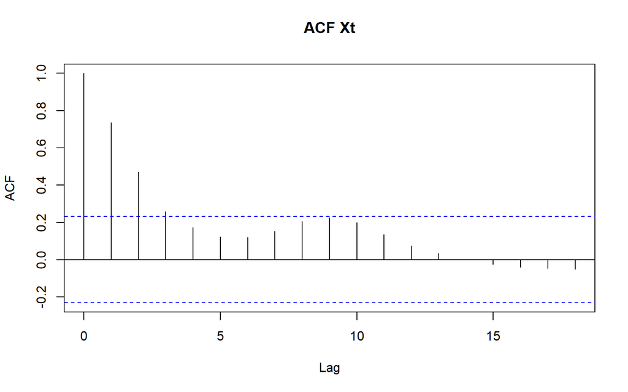

```r
acf(data$Xt, main="ACF Xt")
```

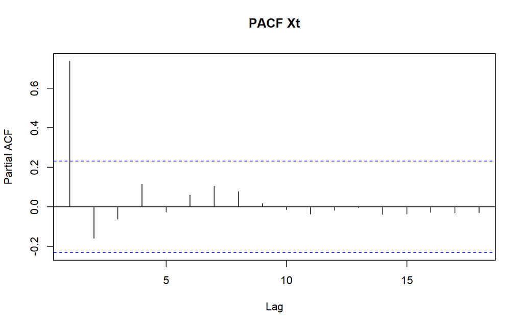

```r
pacf(data$Xt, main="PACF Xt")
```

```r
adf.test(na.omit(data$Yt))
```

```
##
##  Augmented Dickey-Fuller Test
##
## data:  na.omit(data$Yt)
## Dickey-Fuller = -3.4572, Lag order = 4, p-value = 0.05349
## alternative hypothesis: stationary
```

```r
adf.test(na.omit(data$Yt))
```

```
##
##  Augmented Dickey-Fuller Test
##
## data:  na.omit(data$Yt)
## Dickey-Fuller = -3.4572, Lag order = 4, p-value = 0.05349
## alternative hypothesis: stationary
```

### Eksplorasi Kondisi Gauss-Markov

```r
model <- lm(Yt ~ Xt, data = data)
model
```

```
##
## Call:
## lm(formula = Yt ~ Xt, data = data)
##
## Coefficients:
## (Intercept)           Xt
##      29.883       -1.613
```

```r
summary(model)
```

```
##
## Call:
## lm(formula = Yt ~ Xt, data = data)
##
## Residuals:
##     Min      1Q  Median      3Q     Max
## -5.8983 -1.3300 -0.0744  1.6846  9.4099
##
## Coefficients:
##             Estimate Std. Error t value Pr(>|t|)
## (Intercept)  29.8829     1.2447  24.007  < 2e-16 ***
## Xt           -1.6129     0.5216  -3.092  0.00285 **
## ---
## Signif. codes:  0 '***' 0.001 '**' 0.01 '*' 0.05 '.' 0.1 ' ' 1
##
## Residual standard error: 2.886 on 70 degrees of freedom
## Multiple R-squared:  0.1202, Adjusted R-squared:  0.1076
## F-statistic: 9.561 on 1 and 70 DF,  p-value: 0.002854
```

```r
# Residual & fitted
res <- resid(model); fit <- fitted(model)
```

```r
# (1) E(u)=0 ?
mean(res)
```

```
## [1] 2.40985e-16
```

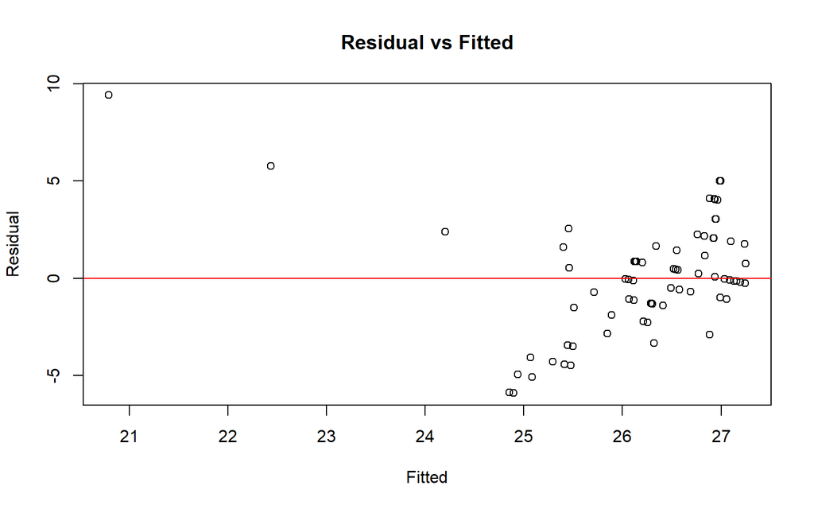

```r
# (2) Homoskedastisitas: plot & uji Breusch–Pagan
plot(fit, res, xlab="Fitted", ylab="Residual", main="Residual vs Fitted"); abline(h=0, col="red")
```

```r
bptest(model)
```

```
##
##  studentized Breusch-Pagan test
##
## data:  model
## BP = 36.881, df = 1, p-value = 1.256e-09
```

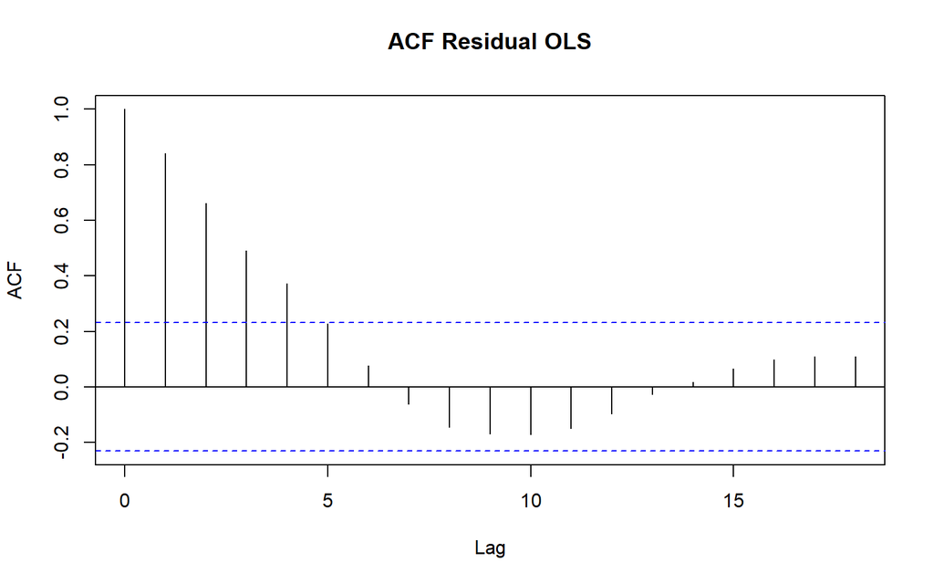

```r
# (3) Autokorelasi residual: ACF & uji Durbin–Watson / Breusch–Godfrey
acf(res, main="ACF Residual OLS")
```

```r
dwtest(model)               # autokorelasi lag-1
```

```
##
##  Durbin-Watson test
##
## data:  model
## DW = 0.15582, p-value < 2.2e-16
## alternative hypothesis: true autocorrelation is greater than 0
```

```r
bgtest(model, order=12)
```

```
##
##  Breusch-Godfrey test for serial correlation of order up to 12
##
## data:  model
## LM test = 55.247, df = 12, p-value = 1.635e-07
```

```r
library(lmtest); library(sandwich)
coeftest(model, vcov = NeweyWest(model, lag = 12, prewhite = FALSE))
```

```
##
## t test of coefficients:
##
##             Estimate Std. Error t value  Pr(>|t|)
## (Intercept)  29.8829     4.0695  7.3432 2.945e-10 ***
## Xt           -1.6129     1.8610 -0.8667    0.3891
## ---
## Signif. codes:  0 '***' 0.001 '**' 0.01 '*' 0.05 '.' 0.1 ' ' 1
```

**Kesimpulan:**

Berdasarkan eksplorasi kondisi Gauss-Markov, diperoleh bahwa model regresi linier sederhana $Y_t$ ~ $X_t$ belum mampu menjelaskan dinamika AQI secara memadai. Secara rata-rata, residual sudah mendekati nol sehingga asumsi ekspektasi error terpenuhi. Namun, dua asumsi penting Gauss–Markov dilanggar:

1. **Heteroskedastisitas:** Hasil uji Breusch–Pagan menunjukkan nilai BP yang sangat signifikan (p < 0.001), sehingga varians error tidak konstan. Hal ini menandakan adanya ketidakstabilan sebaran residual.
2. **Autokorelasi:** Uji Durbin–Watson maupun Breusch–Godfrey menegaskan adanya autokorelasi residual hingga beberapa lag. Plot ACF residual juga memperlihatkan pola korelasi yang jelas antar periode.

   Kondisi ini menyebabkan estimator OLS masih bersifat unbiased, tetapi tidak lagi efisien, dan uji signifikansi dengan standar error biasa menjadi tidak valid. Ketika dilakukan koreksi dengan **Newey–West (HAC)**, hasilnya menunjukkan bahwa pengaruh variabel $X_t$  terhadap $Y_t$ tidak signifikan secara statistik. Artinya, variasi AQI lebih banyak ditentukan oleh dinamika dirinya sendiri (lag $Y$) dibandingkan oleh hubungan kontemporer dengan polutan $X_t$.

   Temuan ini memberikan landasan kuat untuk beralih dari model OLS sederhana menuju **pemodelan deret waktu dinamis** yang dapat mengakomodasi memori data dan pola autokorelasi. Beberapa model kandidat yang relevan untuk dieksplorasi lebih lanjut adalah:
   - **Model Koyck** (memasukkan $Y_{t-1}$ dan $X_t$ )
   - **Distributed Lag Model** (memasukkan $X_t$ beserta beberapa lag X)
   - **Autoregressive Model (AR)** (memasukkan lag Y saja)

   Ketiga model ini akan dibandingkan kinerjanya, khususnya dengan ukuran akurasi prediksi seperti **Mean Absolute Percentage Error (MAPE)** pada data uji, untuk menemukan model terbaik yang paling tepat merepresentasikan dinamika AQI.

# Pembagian Data

```r
# SPLIT DATA
train <- data[1:58,]
test <- data[58:72,]

#data time series
train.ts <- ts(train)
test.ts <- ts(test)
data.ts <- ts(data)
```

# Pemodelan

## Model Koyck

```r
#koyckDlm(x , y , intercept)
```

```r
model.koyck <- koyckDlm(x = train$Xt, y = train$Yt)
summary(model.koyck)
```

```
##
## Call:
## "Y ~ (Intercept) + Y.1 + X.t"
##
## Residuals:
##      Min       1Q   Median       3Q      Max
## -2.14443 -0.61319  0.03512  0.48195  2.18725
##
## Coefficients:
##             Estimate Std. Error t value Pr(>|t|)
## (Intercept)   4.0771     1.8299   2.228   0.0301 *
## Y.1           0.8897     0.0588  15.131   <2e-16 ***
## X.t          -0.5723     0.2854  -2.005   0.0500 *
## ---
## Signif. codes:  0 '***' 0.001 '**' 0.01 '*' 0.05 '.' 0.1 ' ' 1
##
## Residual standard error: 0.9279 on 54 degrees of freedom
## Multiple R-Squared: 0.8273,  Adjusted R-squared: 0.8209
## Wald test: 129.1 on 2 and 54 DF,  p-value: < 2.2e-16
##
## Diagnostic tests:
## NULL
##
##                             alpha       beta       phi
## Geometric coefficients:  36.94716 -0.5722988 0.8896496
```

```r
AIC(model.koyck)
```

```
## [1] 158.1481
```

```r
BIC(model.koyck)
```

```
## [1] 166.3203
```

**Interpretasi Hasil:**

- Dari `summary`, kita dapatkan model:

  $$\hat{Y_t}=4.0771-0.5723X_t+0.8897Y_{t-1}$$

  Koefisien $X_t$ (-0.5723) signifikan, artinya nilai $X$ saat ini berpengaruh terhadap $Y$.
- Koefisien $Y_{t−1}$ (0.8897) juga signifikan. Ini adalah **estimasi untuk** $\lambda$. Nilai ini menunjukkan bahwa sekitar 88% dari efek di periode sebelumnya masih “terbawa” ke periode saat ini.

### Peramalan dan Akurasi

Berikut adalah hasil peramalan $Y$ untuk 15 periode kedepan menggunakan Model Koyck.

```r
fore.koyck <- forecast(model = model.koyck, x = test$Xt, h = 15)
fore.koyck
```

```
## $forecasts
##  [1] 23.10773 23.06075 22.88514 22.68225 22.47164 22.30040 22.21332 22.20994
##  [9] 22.24985 22.30884 22.36726 22.42345 22.45631 22.46438 22.49110
##
## $call
## forecast.koyckDlm(model = model.koyck, x = test$Xt, h = 15)
##
## attr(,"class")
## [1] "forecast.koyckDlm" "dLagM"
```

```r
mape.koyck <- MAPE(fore.koyck$forecasts, test$Yt)
mape.koyck #data test
```

```
## [1] 0.1004493
```

```r
#akurasi data training
GoF(model.koyck)
```

```
##              n       MAE          MPE       MAPE      sMAPE     MASE       MSE
## model.koyck 57 0.6909776 -0.001122737 0.02589331 0.02582947 1.040181 0.8157075
##                  MRAE    GMRAE
## model.koyck 757377131 11372.75
```

## Regressive with Distributed Lag

### Pemilihan Lag Awal

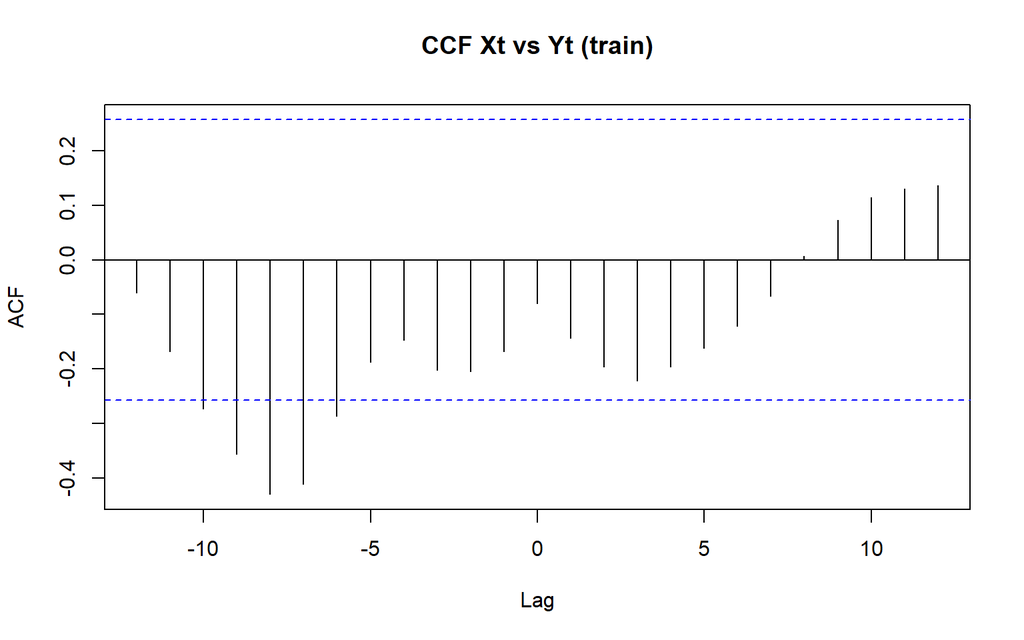

```r
ccf(train$Xt, train$Yt, lag.max = 12, main="CCF Xt vs Yt (train)")
```

### Lag Optimum

Lag paling optimum akan dicari berdasarkan kriteria informasi seperti AIC (Akaike Information Criterion). AIC menyeimbangkan antara kecocokan model dengan kompleksitasnya.

```r
#penentuan lag optimum
finiteDLMauto(formula = Yt ~ Xt,
              data = data.frame(train), q.min = 1, q.max = 6, model.type = "dlm", error.type = "AIC", trace = TRUE)
```

```
##   q - k    MASE      AIC      BIC    GMRAE   MBRAE R.Adj.Sq    Ljung-Box
## 6     6 1.73867 201.1051 218.6663 22650.85 0.56392  0.54223 4.524737e-10
## 5     5 1.75280 204.0813 219.8436 23085.14 1.65593  0.53463 6.980942e-10
## 4     4 1.85610 209.9314 223.8543 31881.26 0.72405  0.50086 2.767593e-09
## 3     3 2.13163 220.3167 232.3607 38604.33 0.77447  0.42645 1.445641e-09
## 2     2 2.18873 233.0605 243.1873 29920.77 0.56412  0.30506 1.907737e-06
## 1     1 2.28775 246.7199 254.8921 24669.65 0.75741  0.15281 5.737415e-09
```

Berdasarkan output tersebut, lag optimum didapatkan ketika lag = 6. Selanjutnya dilakukan pemodelan untuk lag = 6.

```r
#model dlm dengan lag optimum
model.dlm <- dlm(x = train$Xt,y = train$Yt , q = 6)
summary(model.dlm)
```

```
##
## Call:
## lm(formula = model.formula, data = design)
##
## Residuals:
##     Min      1Q  Median      3Q     Max
## -2.2235 -0.8533 -0.2019  0.8476  3.4454
##
## Coefficients:
##             Estimate Std. Error t value Pr(>|t|)
## (Intercept)  37.8700     1.9526  19.395  < 2e-16 ***
## x.t         -12.0761     4.3371  -2.784  0.00788 **
## x.1          10.8089     9.6582   1.119  0.26915
## x.2          -6.1607     9.9498  -0.619  0.53899
## x.3           1.7380     5.6115   0.310  0.75823
## x.4           2.1740     3.1512   0.690  0.49388
## x.5          -0.1957     3.1999  -0.061  0.95152
## x.6          -1.4558     1.5447  -0.942  0.35109
## ---
## Signif. codes:  0 '***' 0.001 '**' 0.01 '*' 0.05 '.' 0.1 ' ' 1
##
## Residual standard error: 1.53 on 44 degrees of freedom
## Multiple R-squared:  0.6051, Adjusted R-squared:  0.5422
## F-statistic:  9.63 on 7 and 44 DF,  p-value: 3.36e-07
##
## AIC and BIC values for the model:
##        AIC      BIC
## 1 201.1051 218.6663
```

Dari hasil tersebut terdapat peubah yang berpengaruh signifikan terhadap taraf nyata 5% yaitu $x_t$ . Adapun keseluruhan model yang terbentuk adalah

$$\hat{Y_t}=37.8700-12.0761X_t$$

Adapun hasil peramalan 15 periode kedepan menggunakan model tersebut adalah sebagai berikut

```r
#peramalan dan akurasi
fore.dlm <- forecast(model = model.dlm, x = test$Xt, h = 15)

#akurasi data test
mape.dlm<- MAPE(fore.dlm$forecasts, test$Yt)
mape.dlm
```

```
## [1] 0.1161142
```

```r
#akurasi data training
GoF(model.dlm)
```

```
##            n     MAE          MPE       MAPE     sMAPE     MASE      MSE
## model.dlm 52 1.12502 -0.002473845 0.04057471 0.0406405 1.738668 1.980551
##                 MRAE    GMRAE
## model.dlm 5859622877 22650.85
```

# Model Autoregressive

```r
# cari nilai p
library(dynlm)

aics <- sapply(1:6, function(pp){
  fm <- dynlm(Yt ~ L(Yt, 1:pp), data = train.ts)
  AIC(fm)
})
data.frame(p = 1:6, AIC = aics)
```

```
##   p      AIC
## 1 1 160.6660
## 2 2 142.3338
## 3 3 139.6557
## 4 4 139.6490
## 5 5 133.9844
## 6 6 133.6965
```

```r
model.ardl <- ardlDlm(x = train$Xt, y = train$Yt, p = 6 , q = 6)
summary(model.ardl)
```

```
##
## Time series regression with "ts" data:
## Start = 7, End = 58
##
## Call:
## dynlm(formula = as.formula(model.text), data = data, start = 1)
##
## Residuals:
##      Min       1Q   Median       3Q      Max
## -0.95569 -0.40044 -0.07243  0.39344  1.54498
##
## Coefficients:
##             Estimate Std. Error t value Pr(>|t|)
## (Intercept) 11.12372    3.42292   3.250  0.00242 **
## X.t         -3.69516    2.27531  -1.624  0.11264
## X.1          3.89181    5.00757   0.777  0.44186
## X.2          3.25291    5.28263   0.616  0.54171
## X.3         -6.75041    3.13266  -2.155  0.03757 *
## X.4          2.83119    1.55799   1.817  0.07708 .
## X.5         -0.22028    1.58040  -0.139  0.88988
## X.6         -0.66880    0.76262  -0.877  0.38601
## Y.1          0.92192    0.16559   5.567 2.23e-06 ***
## Y.2          0.06815    0.22986   0.296  0.76848
## Y.3          0.05849    0.22145   0.264  0.79311
## Y.4         -0.14762    0.21932  -0.673  0.50496
## Y.5         -0.17404    0.23033  -0.756  0.45453
## Y.6         -0.03383    0.14653  -0.231  0.81863
## ---
## Signif. codes:  0 '***' 0.001 '**' 0.01 '*' 0.05 '.' 0.1 ' ' 1
##
## Residual standard error: 0.6934 on 38 degrees of freedom
## Multiple R-squared:  0.9299, Adjusted R-squared:  0.906
## F-statistic:  38.8 on 13 and 38 DF,  p-value: < 2.2e-16
```

```r
AIC(model.ardl)
```

```
## [1] 123.1754
```

```r
BIC(model.ardl)
```

```
## [1] 152.4441
```

```r
model.ardl <- ardlDlm(formula = Yt ~ Xt,
                         data = train,p = 6 , q = 6)
summary(model.ardl)
```

```
##
## Time series regression with "ts" data:
## Start = 7, End = 58
##
## Call:
## dynlm(formula = as.formula(model.text), data = data)
##
## Residuals:
##      Min       1Q   Median       3Q      Max
## -0.95569 -0.40044 -0.07243  0.39344  1.54498
##
## Coefficients:
##             Estimate Std. Error t value Pr(>|t|)
## (Intercept) 11.12372    3.42292   3.250  0.00242 **
## Xt.t        -3.69516    2.27531  -1.624  0.11264
## Xt.1         3.89181    5.00757   0.777  0.44186
## Xt.2         3.25291    5.28263   0.616  0.54171
## Xt.3        -6.75041    3.13266  -2.155  0.03757 *
## Xt.4         2.83119    1.55799   1.817  0.07708 .
## Xt.5        -0.22028    1.58040  -0.139  0.88988
## Xt.6        -0.66880    0.76262  -0.877  0.38601
## Yt.1         0.92192    0.16559   5.567 2.23e-06 ***
## Yt.2         0.06815    0.22986   0.296  0.76848
## Yt.3         0.05849    0.22145   0.264  0.79311
## Yt.4        -0.14762    0.21932  -0.673  0.50496
## Yt.5        -0.17404    0.23033  -0.756  0.45453
## Yt.6        -0.03383    0.14653  -0.231  0.81863
## ---
## Signif. codes:  0 '***' 0.001 '**' 0.01 '*' 0.05 '.' 0.1 ' ' 1
##
## Residual standard error: 0.6934 on 38 degrees of freedom
## Multiple R-squared:  0.9299, Adjusted R-squared:  0.906
## F-statistic:  38.8 on 13 and 38 DF,  p-value: < 2.2e-16
```

```r
AIC(model.ardl)
```

```
## [1] 123.1754
```

```r
BIC(model.ardl)
```

```
## [1] 152.4441
```

## Peramalan dan Akurasi

```r
fore.ardl <- forecast(model = model.ardl, x= test$Xt, h = 15)
fore.ardl
```

```
## $forecasts
##  [1] 23.50549 23.14307 21.67176 22.96295 23.39281 23.34537 24.20912 24.70513
##  [9] 24.54736 24.43730 24.37697 24.11978 23.77626 23.47833 23.64559
##
## $call
## forecast.ardlDlm(model = model.ardl, x = test$Xt, h = 15)
##
## attr(,"class")
## [1] "forecast.ardlDlm" "dLagM"
```

```r
mape.ardl <- MAPE(fore.ardl$forecasts, test$Yt)
mape.ardl
```

```
## [1] 0.1278653
```

```r
#akurasi data training
GoF(model.ardl)
```

```
##             n       MAE           MPE       MAPE      sMAPE      MASE       MSE
## model.ardl 52 0.4730397 -0.0004494207 0.01738975 0.01742008 0.7310614 0.3513256
##                  MRAE  GMRAE
## model.ardl 1583356550 9421.5
```

## Lag Optimum

```r
#penentuan lag optimum
model.ardl.opt <- ardlBoundOrders(data = data.frame(data), ic = "AIC",
                                  formula = Yt ~ Xt )
model.ardl.opt
```

```
## $p
##   Xt
## 1 15
##
## $q
## [1] 5
##
## $Stat.table
##           q = 1    q = 2    q = 3    q = 4    q = 5    q = 6    q = 7    q = 8
## p = 1  175.6638 173.4300 169.4588 153.4179 153.0743 151.1206 144.9328 145.9197
## p = 2  173.3465 173.4835 170.1115 155.4157 151.3281 145.4609 142.2415 143.1635
## p = 3  170.6630 170.6630 172.0632 157.3058 152.4389 143.5828 142.5900 143.5356
## p = 4  153.4709 155.4432 155.4432 154.6363 149.6701 143.3774 144.5209 145.4322
## p = 5  147.2972 149.2970 151.2887 151.2887 151.4674 144.9280 145.9614 145.3283
## p = 6  137.8965 139.8447 141.7903 143.1942 143.1942 144.0834 144.8809 142.7234
## p = 7  148.4421 148.5238 148.1127 146.0607 143.4367 143.4367 145.4223 143.8002
## p = 8  140.5719 141.0397 141.8280 141.9797 140.7112 141.2079 141.2079 143.0516
## p = 9  146.2825 142.3373 141.1879 140.7472 139.5962 141.0394 142.4976 142.4976
## p = 10 150.4402 144.7181 142.6828 141.9912 139.6346 141.4725 142.6619 144.6327
## p = 11 148.7483 142.8007 139.5594 139.2561 130.4437 132.4436 133.3735 135.3613
## p = 12 145.6517 138.8176 135.5105 134.9701 127.4923 128.8063 129.3052 131.2456
## p = 13 147.6700 138.8567 136.2592 137.1445 131.6268 133.5459 134.9739 136.9144
## p = 14 147.9332 139.5295 135.8578 136.4160 132.8957 134.8866 136.5186 138.3974
## p = 15 145.2797 135.1519 132.2959 133.0945 124.7089 126.7065 128.6573 130.6374
##           q = 9   q = 10   q = 11   q = 12   q = 13   q = 14   q = 15
## p = 1  146.1822 145.1524 141.7981 141.7971 136.3636 134.9485 133.7805
## p = 2  142.4039 143.1442 140.0579 137.3658 134.7689 135.3957 134.3190
## p = 3  143.3060 143.9315 140.8152 138.0758 136.6450 137.0960 136.2864
## p = 4  145.1476 145.8591 142.5665 140.0567 138.5906 139.0671 138.2374
## p = 5  143.3443 143.3033 138.7263 138.5509 138.2344 138.2887 136.5913
## p = 6  143.7239 144.6324 140.0156 139.9542 140.1107 140.2790 138.5596
## p = 7  144.9764 145.8288 139.9750 138.0631 137.1651 135.0759 135.5428
## p = 8  144.3615 144.4638 140.6567 133.8244 132.9980 132.6996 132.4038
## p = 9  144.3583 144.6840 138.0590 135.8007 134.6425 134.2178 134.2594
## p = 10 144.6327 146.5713 139.5722 137.7714 136.3764 136.1647 136.2013
## p = 11 136.1546 136.1546 136.7182 135.6091 133.8928 133.6618 134.8254
## p = 12 132.3942 134.3067 134.3067 135.1873 133.4581 134.0468 133.2658
## p = 13 136.7088 137.5455 136.5324 136.5324 135.2556 135.7380 135.2432
## p = 14 137.0029 136.2761 133.5555 135.2334 135.2334 137.1634 136.2598
## p = 15 132.0212 132.1933 129.1212 131.1030 131.3276 131.3276 133.0357
##
## $min.Stat
## [1] 124.7089
```

```r
min_p=c()
for(i in 1:6){
  min_p[i]=min(model.ardl.opt$Stat.table[[i]])
}
q_opt=which(min_p==min(min_p, na.rm = TRUE))
p_opt=which(model.ardl.opt$Stat.table[[q_opt]] ==
              min(model.ardl.opt$Stat.table[[q_opt]], na.rm = TRUE))
data.frame("q_optimum" = q_opt, "p_optimum" = p_opt,
           "AIC"=model.ardl.opt$min.Stat)
```

```
##   q_optimum p_optimum      AIC
## 1         5        15 124.7089
```

```r
model.ardl2 <- ardlDlm(formula = Yt ~ Xt,
                         data = train,p = 5, q = 15)
summary(model.ardl2)
```

```
##
## Time series regression with "ts" data:
## Start = 16, End = 58
##
## Call:
## dynlm(formula = as.formula(model.text), data = data)
##
## Residuals:
##      Min       1Q   Median       3Q      Max
## -0.91660 -0.29226 -0.00501  0.23432  1.09377
##
## Coefficients:
##             Estimate Std. Error t value Pr(>|t|)
## (Intercept) 12.56640    4.55290   2.760  0.01173 *
## Xt.t        -8.68055    2.87615  -3.018  0.00654 **
## Xt.1         9.58795    7.29011   1.315  0.20262
## Xt.2         4.23196    8.90356   0.475  0.63947
## Xt.3        -3.66433    8.33210  -0.440  0.66459
## Xt.4        -1.59616    6.75758  -0.236  0.81556
## Xt.5        -1.62277    3.74347  -0.433  0.66908
## Yt.1         0.60080    0.22217   2.704  0.01328 *
## Yt.2         0.41292    0.27697   1.491  0.15088
## Yt.3         0.22054    0.26429   0.834  0.41343
## Yt.4        -0.22907    0.25103  -0.913  0.37186
## Yt.5        -0.14770    0.24130  -0.612  0.54705
## Yt.6        -0.25492    0.24178  -1.054  0.30372
## Yt.7         0.05341    0.26181   0.204  0.84031
## Yt.8         0.03734    0.25996   0.144  0.88717
## Yt.9         0.02858    0.23665   0.121  0.90502
## Yt.10        0.01514    0.23353   0.065  0.94892
## Yt.11       -0.15826    0.22520  -0.703  0.48994
## Yt.12        0.04416    0.21940   0.201  0.84243
## Yt.13        0.05481    0.22383   0.245  0.80893
## Yt.14        0.03882    0.21598   0.180  0.85909
## Yt.15       -0.04700    0.13874  -0.339  0.73817
## ---
## Signif. codes:  0 '***' 0.001 '**' 0.01 '*' 0.05 '.' 0.1 ' ' 1
##
## Residual standard error: 0.6204 on 21 degrees of freedom
## Multiple R-squared:  0.9609, Adjusted R-squared:  0.9217
## F-statistic: 24.54 on 21 and 21 DF,  p-value: 2.137e-10
```

```r
AIC(model.ardl2)
```

```
## [1] 96.15545
```

Dari tabel di atas, dapat terlihat bahwa nilai AIC terendah didapat ketika $p = 15$ dan $q = 5$, yaitu sebesar `124.7089`. Artinya, model autoregressive optimum didapat ketika $p = 15$ dan $q = 5$.

# Perbandingan Model

```r
akurasi <- matrix(c(mape.koyck, mape.dlm, mape.ardl))
row.names(akurasi)<- c("Koyck","DLM","Autoregressive")
colnames(akurasi) <- c("MAPE")
akurasi
```

```
##                     MAPE
## Koyck          0.1004493
## DLM            0.1161142
## Autoregressive 0.1278653
```

Berdasarkan nilai MAPE, model paling optimum didapat pada Model Koyck karena memiliki nilai MAPE yang terkecil.